# AS3-0 Group-0

劉育銘 M064020025

```r
rm(list=ls(all=T))
options(digits=4, scipen=12)
library(dplyr); library(ggplot2)
```

### 【A】 Definitions

#### 機率、勝率(Odd)、Logit

- Odd = $p/(1-p)$
- Logit = $log(odd)$ = $log(\frac{p}{1=p})$
- $o = p/(1-p)$ ; $p = o/(1+o)$ ; $logit = log(o)$

```r
par(cex=0.8, mfcol=c(1,2))
curve(x/(1-x), 0.02, 0.98, col='cyan',lwd=2, main='odd')
abline(v=seq(0,1,0.1), h=seq(0,50,5), col='lightgray', lty=3)
```

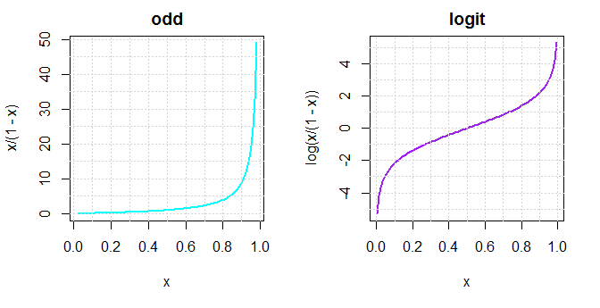

```r
curve(log(x/(1-x)), 0.005, 0.995, lwd=2, col='purple', main="logit")
abline(v=seq(0,1,0.1), h=seq(-5,5,1), col='lightgray', lty=3)
```

#### Logistic Function & Logistic Regression

- Linear Model: $y = f(x) = b_0 + b_1x_1 + b_2x_2 + ...$
- General Linear Model(GLM): $y = Link(f(x))$
- Logistic Regression: $logit(y) = log(\frac{p}{1-p}) = f(x) \text{ where } p = prob[y=1]$
- Logistic Function: $Logistic(F_x) = \frac{1}{1+Exp(-F_x)} = \frac{Exp(F_x)}{1+Exp(F_x)}$

```r
par(cex=0.8)
curve(1/(1+exp(-x)), -5, 5, col='blue', lwd=2,main="Logistic Function",
      xlab="f(x): the logit of y = 1", ylab="the probability of y = 1")
abline(v=-5:5, h=seq(0,1,0.1), col='lightgray', lty=2)
```

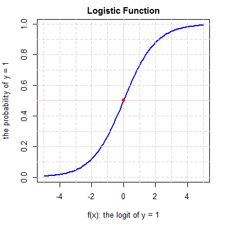

```r
abline(v=0,h=0.5,col='pink')
points(0,0.5,pch=20,cex=1.5,col='red')
```

### 【B】`glm(, family=binomial)`

`glm()`的功能：在 $\{x\}$ 的空間之中，找出區隔 $y$ 的(類別)界線

```r
getwd()
```

```
[1] "C:/RXGithub/logistic-Regression"
```

```r
Q = read.csv("./data/quality.csv")  # Read in dataset
glm1 = glm(PoorCare~OfficeVisits+Narcotics, Q, family=binomial)
summary(glm1)
```

```
Call:
glm(formula = PoorCare ~ OfficeVisits + Narcotics, family = binomial,
    data = Q)

Deviance Residuals:
   Min      1Q  Median      3Q     Max
-2.377  -0.627  -0.510  -0.154   2.119

Coefficients:
             Estimate Std. Error z value    Pr(>|z|)
(Intercept)   -2.5402     0.4500   -5.64 0.000000017
OfficeVisits   0.0627     0.0240    2.62     0.00892
Narcotics      0.1099     0.0326    3.37     0.00076

(Intercept)  ***
OfficeVisits **
Narcotics    ***
---
Signif. codes:
0 ‘***’ 0.001 ‘**’ 0.01 ‘*’ 0.05 ‘.’ 0.1 ‘ ’ 1

(Dispersion parameter for binomial family taken to be 1)

    Null deviance: 147.88  on 130  degrees of freedom
Residual deviance: 116.45  on 128  degrees of freedom
AIC: 122.4

Number of Fisher Scoring iterations: 5
```

```r
b = coef(glm1); b   # extract the regression coef
```

```
 (Intercept) OfficeVisits    Narcotics
    -2.54021      0.06273      0.10990
```

Given `OfficeVisits=3, Narcotics=4`, what are the predicted logit, odd and probability?

```r
logit = sum(b * c(1, 3, 4))
odd = exp(logit)
prob = odd/(1+odd)
c(logit=logit, odd=odd, prob=prob)
```

```
  logit     odd    prob
-1.9124  0.1477  0.1287
```

【**Q**】What if `OfficeVisits=2, Narcotics=3`?

```r
logit = sum(b * c(1, 2, 3))
odd = exp(logit)
prob = odd/(1+odd)
c(logit=logit, odd=odd, prob=prob)
```

```
  logit     odd    prob
-2.0851  0.1243  0.1106
```

We can plot the line of `logit = 0` or `prob = 0.5` on the plane of $X$

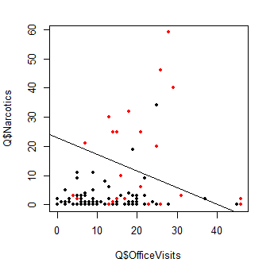

```r
par(cex=0.8)
plot(Q$OfficeVisits, Q$Narcotics, col=1+Q$PoorCare,pch=20)
abline(-b[1]/b[3], -b[2]/b[3])
```

Furthermore, we can translate probability, logit and coefficents to intercept & slope …

$$f(x) = b_1 + b_2 x_2 + b_3 x_3 = g \Rightarrow x_3 = \frac{g - b_1}{b_3} - \frac{b_2}{b_3}x_2$$

```r
p = seq(0.1,0.9,0.1)
logit = log(p/(1-p))
data.frame(prob = p, logit)
```

| prob | logit |
| --- | --- |
| 0.1 | -2.1972 |
| 0.2 | -1.3863 |
| 0.3 | -0.8473 |
| 0.4 | -0.4055 |
| 0.5 | 0.0000 |
| 0.6 | 0.4055 |
| 0.7 | 0.8473 |
| 0.8 | 1.3863 |
| 0.9 | 2.1972 |

then mark the contours of proabilities into the scatter plot

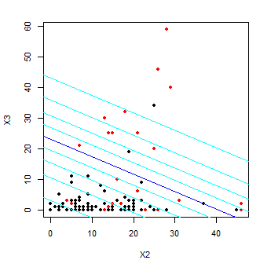

```r
par(cex=0.7)
plot(Q$OfficeVisits, Q$Narcotics, col=1+Q$PoorCare,
     pch=20, cex=1.3, xlab='X2', ylab='X3')
for(g in logit) {
  abline((g-b[1])/b[3], -b[2]/b[3], col=ifelse(g==0,'blue','cyan')) }
```

【**Q**】What do the blue/cyan lines means? A:機率為0.1~0.9的線

【**Q**】Given any point in the figure above, how can you tell its (predicted) probability approximately? A:我們可以畫一條機率為0.5的線， 點若位在線的右方機率>0.5 位於線的左方機率<0.5

### 【C】The Confusion Matrix

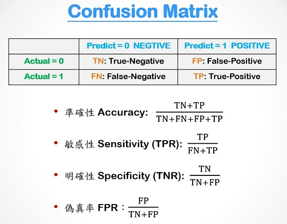

Figure 1 - Confusion Matrix

### 【D】The Distribution of Predicted Probability (DPP)

Confusion matrix is not fixed. It changes by `Threshold` …

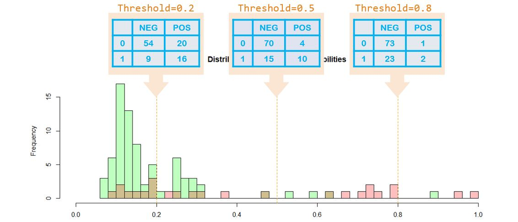

Figure 2 - Dist. Prediected Prob.

```r
library(caTools)
DPP2 = function(pred,class,tvalue,breaks=0.01) {
  mx = table(class == tvalue, pred > 0.5)
  tn = sum(class != tvalue & pred <= 0.5)
  fn = sum(class == tvalue & pred <= 0.5)
  fp = sum(class != tvalue & pred > 0.5)
  tp = sum(class == tvalue & pred > 0.5)
  acc = (tn + tp)/length(pred)
  sens = tp/(fn+tp)
  spec = tn/(tn+fp)
  auc = colAUC(pred,class)
  data.frame(pred,class) %>%
    ggplot(aes(x=pred, fill=class)) +
    geom_histogram(col='gray',alpha=0.5,breaks=seq(0,1,breaks)) +
    xlim(0,1) + theme_bw() + xlab("predicted probability") +
    ggtitle(
      sprintf("Distribution of Prob[class = \'%s\']", tvalue),
      sprintf("AUC=%.3f, Acc=%.3f, Sens=%.3f, Spec=%.3f",
              auc, acc, sens, spec) )
  }
```

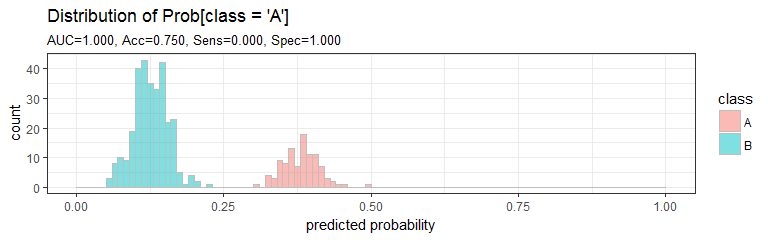

```r
N1 = 300; N2 = 100
DPP2(pred = c(rnorm(N1,0.125,0.03), rnorm(N2,0.375,0.03)),
     class = c(rep('B',N1), rep('A',N2)),
     tvalue = 'A')
```

【**Q**】Is it possible to have `AUC = ACC = SENS = SPEC = 1`? Can you modify the code to make it happen?

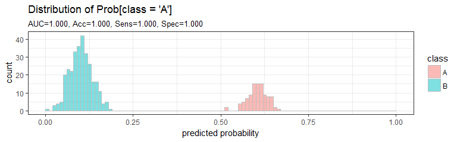

```r
N1 = 300; N2 = 100
DPP2(pred = c(rnorm(N1,0.1,0.03), rnorm(N2,0.6,0.03)),
     class = c(rep('B',N1), rep('A',N2)),
     tvalue = 'A')
```

【**Q**】Is it possible to have `AUC = ACC = SENS = SPEC = 0`? Can you modify the code to make that happen?

A:AUC不可能<0.5,Acc、Sens、Spec可以是0

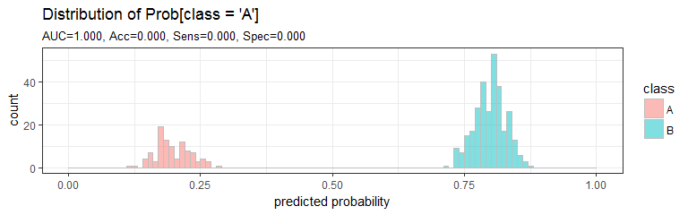

```r
N1 = 300; N2 = 100
DPP2(pred = c(rnorm(N1,0.8,0.03), rnorm(N2,0.2,0.03)),
     class = c(rep('B',N1), rep('A',N2)),
     tvalue = 'A')
```

### 【E】Modeling Expert

#### E1: Random Split

```r
set.seed(88)
split = sample.split(Q$PoorCare, SplitRatio = 0.75)
table(split) %>% prop.table()
```

```
split
 FALSE   TRUE
0.2443 0.7557
```

```r
table(y = Q$PoorCare, split) %>% prop.table(2)
```

```
   split
y    FALSE   TRUE
  0 0.7500 0.7475
  1 0.2500 0.2525
```

```r
TR = subset(Q, split == TRUE)
TS = subset(Q, split == FALSE)
```

#### E2: Build Model

```r
glm1 = glm(PoorCare ~ OfficeVisits + Narcotics, TR, family=binomial)
summary(glm1)
```

```
Call:
glm(formula = PoorCare ~ OfficeVisits + Narcotics, family = binomial,
    data = TR)

Deviance Residuals:
    Min       1Q   Median       3Q      Max
-2.0630  -0.6316  -0.5050  -0.0969   2.1669

Coefficients:
             Estimate Std. Error z value   Pr(>|z|)
(Intercept)   -2.6461     0.5236   -5.05 0.00000043 ***
OfficeVisits   0.0821     0.0305    2.69     0.0072 **
Narcotics      0.0763     0.0321    2.38     0.0173 *
---
Signif. codes:
0 ‘***’ 0.001 ‘**’ 0.01 ‘*’ 0.05 ‘.’ 0.1 ‘ ’ 1

(Dispersion parameter for binomial family taken to be 1)

    Null deviance: 111.888  on 98  degrees of freedom
Residual deviance:  89.127  on 96  degrees of freedom
AIC: 95.13

Number of Fisher Scoring iterations: 4
```

#### E3: Prediction & Evaluation

```r
pred = predict(glm1, type='response')
mx = table(TR$PoorCare, pred > 0.5); mx
```

```
    FALSE TRUE
  0    70    4
  1    15   10
```

```r
c(accuracy = sum(diag(mx))/sum(mx),
  sensitivity = mx[2,2]/sum(mx[2,]),
  specificity = mx[1,1]/sum(mx[1,]))
```

```
   accuracy sensitivity specificity
     0.8081      0.4000      0.9459
```

#### E4: ROC & AUC

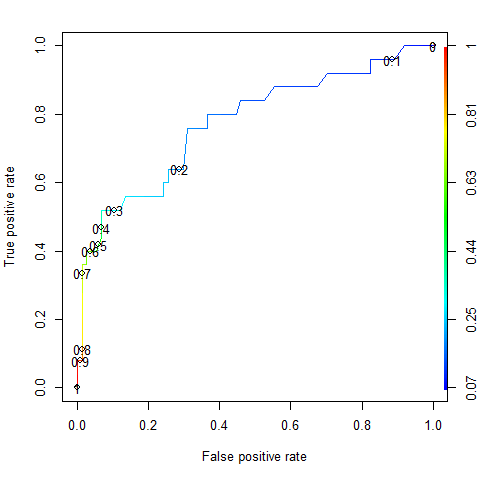

```r
#install.packages('ROCR')
library(ROCR)
ROCRpred = prediction(pred, TR$PoorCare)
ROCRperf = performance(ROCRpred, "tpr", "fpr")
par(cex=0.8)
plot(ROCRperf, colorize=TRUE, print.cutoffs.at=seq(0,1,0.1))
```

```r
as.numeric(performance(ROCRpred, "auc")@y.values)
```

```
[1] 0.7746
```

```r
caTools::colAUC(pred, TR$PoorCare)
```

```
          [,1]
0 vs. 1 0.7746
```

### 【F】Framingham Heart Study

```r
source("DPP.R")
```

[output not shown]

#### F1: Reading & Splitting

#### F2: Logistic Regression Model

#### F3: Prediction & Evaluation

#### F4: AUC & DPP

#### F5: Expected Result & Optimization

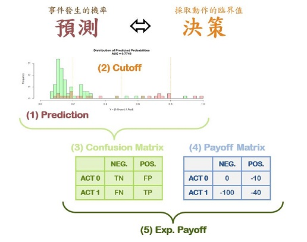

Figure 3 - Startegic Optimization

【**Q**】如果什麼都不做，期望報酬是多少？

【**Q**】如果每位病人都做呢？

【**Q**】在所有的商務情境都是這種狀況嗎？ 不是

【**Q**】你可以模擬出「全做」比「全不做」還要好的狀況、並舉出一個會發生這種狀況的商務情境嗎？

投資新創公司 投資失敗不會賠太多成本 投資成功可能賺很多回來 payoff: [,1] [,2] [1,] 0 -10 [2,] 0 100

#### F6: Simulation

```r
library(manipulate)
p0 = par(mfrow=c(2,1),cex=0.8)
manipulate({
  Y0 = -22000; Y1 = -12000
  mx = matrix(c(true_neg, false_neg, false_pos, true_pos),2,2)
  cx = seq(0.02, 0.64, 0.01)
  rx = sapply(cx, function(p) sum(table(y, pred>p)*mx) )
  i = which.max(rx)
  plot(cx, rx, type='l',col='cyan',lwd=2,main=sprintf(
    "Optomal Expected Result: $%d @ %.2f, T:%d",rx[i],cx[i],sum(pred>cx[i])),
    ylim=c(Y0,Y1))
  abline(v=cx[i],col='red')
  abline(v=seq(0,1,0.1),h=seq(Y0,Y1,2000),col='lightgray',lty=3)
  DPP(pred, y, 1, b=seq(0,1,0.02))
  abline(v=cx[i],col='red')
  },
  true_neg  = slider(-100,100,0,step=5),
  false_neg = slider(-100,100,-100,step=5),
  false_pos = slider(-100,100,-10,step=5),
  true_pos  = slider(-100,100,-60,step=5)
  )
par(p0)
```

【**Q**】有五種成本分別為 `$5, $10, $15, $20, $30` 的藥，它們分別可以將風險成本從 `$100` 降低到 `$70, $60, $50, $40, $25`，哪一種藥的期望效益是最大的呢？

```r
payoff = matrix(c(0,-100,-5,-70),2,2)
cutoff = seq(0.02, 0.7296, 0.01)
table(y,pred>0.02)
```

[output not shown]

### 【G】分析流程：資料、模型、預測、決策

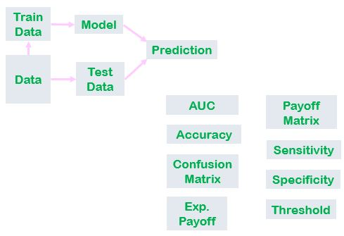

Figure 4 - 資料、模型、預測、決策